# Exercise 2

# Background

The dataset “students2014” contains information from 166 students attending an introductory course at the University of Helsinki. Students answered questions regarding learning approaches. The data contains 7 variables: “age”, “gender”, “attitude” (the global attitude attitude toward statistics), “deep” (higher points indicate a strong need to engage in the actual content), “stra” (higher points indicate strategies used that maximices the the chance to get a high grade) , “surf” (higher points indicate an intention to get trough with least amonut of trouble) and “points” (Exam points).

```r
students2014 <- read.table("~/GitHub/IODS-project/data/learning2018.txt", header=T, sep="\t")
dim(students2014)
```

```
## [1] 166   7
```

```r
str(students2014)
```

```
## 'data.frame':    166 obs. of  7 variables:
##  $ gender  : Factor w/ 2 levels "F","M": 1 2 1 2 2 1 2 1 2 1 ...
##  $ age     : int  53 55 49 53 49 38 50 37 37 42 ...
##  $ attitude: num  3.7 3.1 2.5 3.5 3.7 3.8 3.5 2.9 3.8 2.1 ...
##  $ deep    : num  3.58 2.92 3.5 3.5 3.67 ...
##  $ stra    : num  3.38 2.75 3.62 3.12 3.62 ...
##  $ surf    : num  2.58 3.17 2.25 2.25 2.83 ...
##  $ points  : int  25 12 24 10 22 21 21 31 24 26 ...
```

# Summary data

## Particpant summary

```r
library(knitr)

#print a numeric summary
kable(summary(students2014), caption = "Table 1. Summary of variables in studnets2014 data")
```

Table 1. Summary of variables in studnets2014 data

|  | gender | age | attitude | deep | stra | surf | points |
| --- | --- | --- | --- | --- | --- | --- | --- |
|  | F:110 | Min. :17.00 | Min. :1.400 | Min. :1.583 | Min. :1.250 | Min. :1.583 | Min. : 7.00 |
|  | M: 56 | 1st Qu.:21.00 | 1st Qu.:2.600 | 1st Qu.:3.333 | 1st Qu.:2.625 | 1st Qu.:2.417 | 1st Qu.:19.00 |
|  | NA | Median :22.00 | Median :3.200 | Median :3.667 | Median :3.188 | Median :2.833 | Median :23.00 |
|  | NA | Mean :25.51 | Mean :3.143 | Mean :3.680 | Mean :3.121 | Mean :2.787 | Mean :22.72 |
|  | NA | 3rd Qu.:27.00 | 3rd Qu.:3.700 | 3rd Qu.:4.083 | 3rd Qu.:3.625 | 3rd Qu.:3.167 | 3rd Qu.:27.75 |
|  | NA | Max. :55.00 | Max. :5.000 | Max. :4.917 | Max. :5.000 | Max. :4.333 | Max. :33.00 |

## Distributions

Figure 1 shows the density distributions of each variable. All variables except age looks more or less normally distributed. Age is skewed.Similar distributions is noted among men and women.

## Relationships

Figure 1 also shows correlation coffiecient for the each relationship between variables and scatteplots illustrating the relationship. The strongest correlation is between attitude and points, the variables are moderately positively correlated (Cor=0.437) and similar among women and men (Figure 1 and 2). A moderate negative correlations is observed between deep and surface questions (cor -0.324), which is considerably higher among men (Men: -0.622 vs women:-0.087, Figure 1 and 3). For all other relationships, the correlation is low (<0.30).

```r
library(GGally)
```

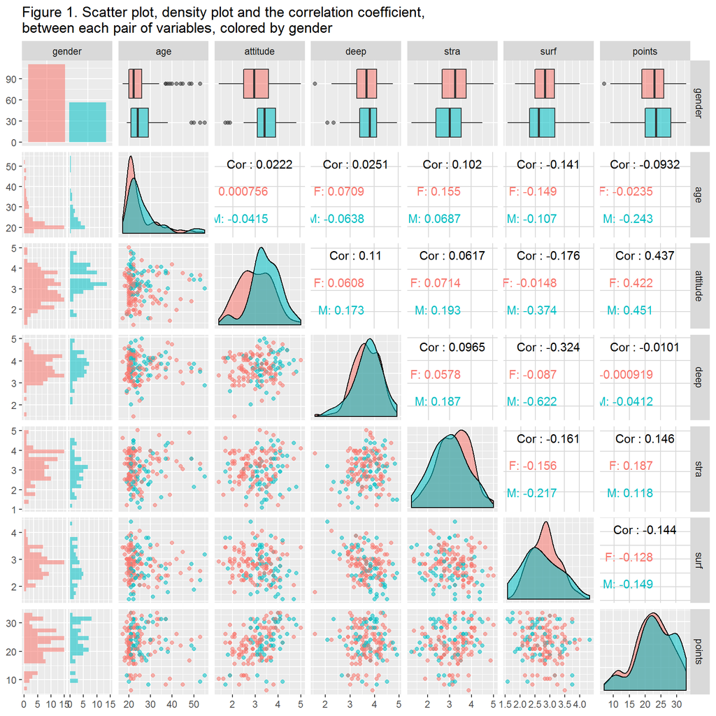

```r
library(ggplot2)

#draw a graphical summary using ggpairs()
p <- ggpairs(students2014, mapping = aes(col=students2014$gender, alpha=0.3), lower = list(combo = wrap("facethist", bins = 20)))

p_final <- p+ ggtitle("Figure 1. Scatter plot, density plot and the correlation coefficient,\nbetween each pair of variables, colored by gender")
p_final
```

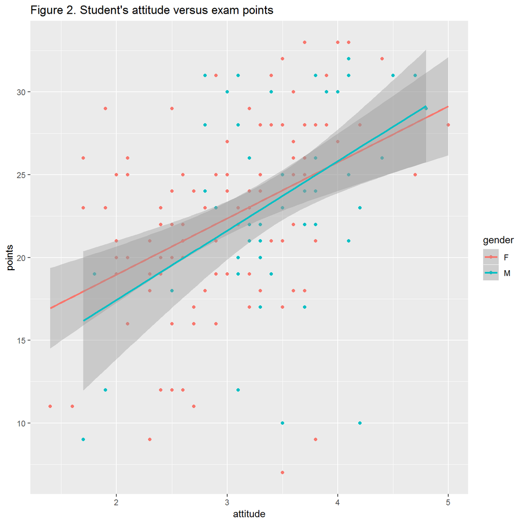

```r
# Access the gglot2 library
library(ggplot2)

# initialize plot with data and aesthetic mapping
p1 <- ggplot(students2014, aes(x = attitude, y = points, col=gender))

# define the visualization type (points), add a regression line
p2 <- p1 + geom_point() + geom_smooth(method = "lm")

# add a main title and draw the plot
p3 <- p2 + ggtitle("Figure 2. Student's attitude versus exam points")
p3
```

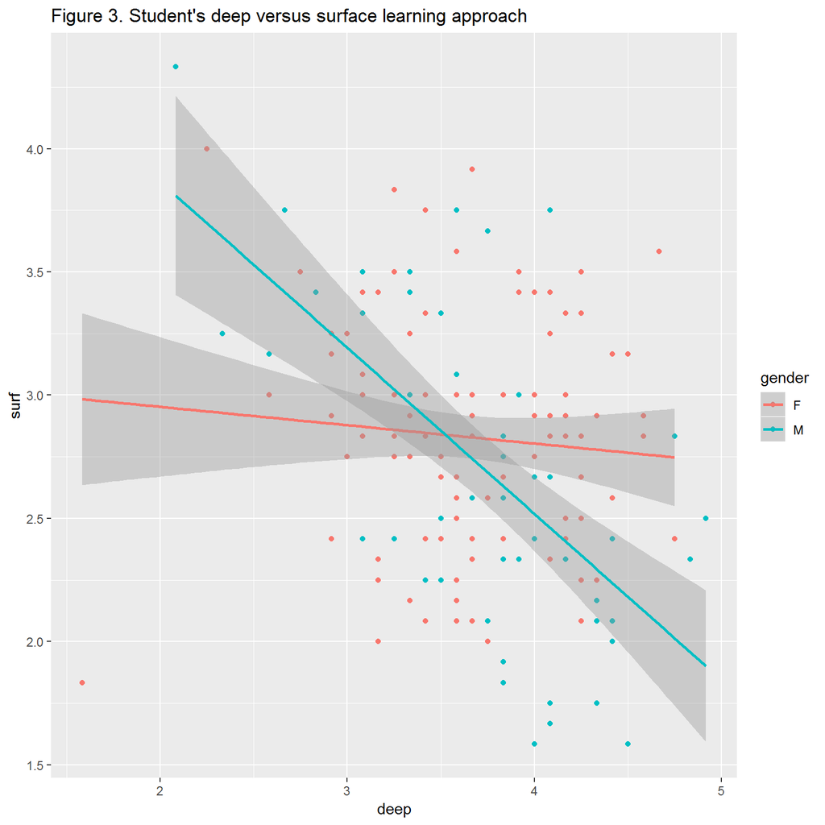

```r
# initialize plot with data and aesthetic mapping
p_1 <- ggplot(students2014, aes(x = deep, y = surf, col=gender))

# define the visualization type (points), and regression line
p_2 <- p_1 + geom_point() + geom_smooth(method = "lm")

# add a main title and draw the plot
p_3 <- p_2 + ggtitle("Figure 3. Student's deep versus surface learning approach")
p_3
```

# Linear regression

We run a linear regression to test how much attitude, age and gender explain the exam points. Of the included variables, there was only a statistically significant relationship between attitude and exam points (P=8.34e-09). Each increase 1 score increase in attitude increased the exam points by 3.6 points. Age and gender was removed from analysis, since they were did statistically significantly associate with exam points and the analysis was rerun.The attitude explained 18.56 % of the variability in Exam points.

```r
my_model <- lm(points ~ attitude+age+gender, data = students2014)

summary(my_model)
```

```
##
## Call:
## lm(formula = points ~ attitude + age + gender, data = students2014)
##
## Residuals:
##      Min       1Q   Median       3Q      Max
## -17.4590  -3.3221   0.2186   4.0247  10.4632
##
## Coefficients:
##             Estimate Std. Error t value Pr(>|t|)
## (Intercept) 13.42910    2.29043   5.863 2.48e-08 ***
## attitude     3.60657    0.59322   6.080 8.34e-09 ***
## age         -0.07586    0.05367  -1.414    0.159
## genderM     -0.33054    0.91934  -0.360    0.720
## ---
## Signif. codes:  0 '***' 0.001 '**' 0.01 '*' 0.05 '.' 0.1 ' ' 1
##
## Residual standard error: 5.315 on 162 degrees of freedom
## Multiple R-squared:  0.2018, Adjusted R-squared:  0.187
## F-statistic: 13.65 on 3 and 162 DF,  p-value: 5.536e-08
```

```r
#rerun

my_model <- lm(points ~ attitude, data = students2014)

summary(my_model)
```

```
##
## Call:
## lm(formula = points ~ attitude, data = students2014)
##
## Residuals:
##      Min       1Q   Median       3Q      Max
## -16.9763  -3.2119   0.4339   4.1534  10.6645
##
## Coefficients:
##             Estimate Std. Error t value Pr(>|t|)
## (Intercept)  11.6372     1.8303   6.358 1.95e-09 ***
## attitude      3.5255     0.5674   6.214 4.12e-09 ***
## ---
## Signif. codes:  0 '***' 0.001 '**' 0.01 '*' 0.05 '.' 0.1 ' ' 1
##
## Residual standard error: 5.32 on 164 degrees of freedom
## Multiple R-squared:  0.1906, Adjusted R-squared:  0.1856
## F-statistic: 38.61 on 1 and 164 DF,  p-value: 4.119e-09
```

## Draw diagnostic plots

The Residual vs fitted plot is used to detect non-linearity, unequal error variances, and outliers, which linear regression assume there is not. Based on the plot it looks like there are some outliers.

The residuals ar located quite randomly around the 0 line, which suggest that the assumption that the relationship is linear correct.

three of residual “stands out” from the pattern of residuals, suggesting there are some outliers.

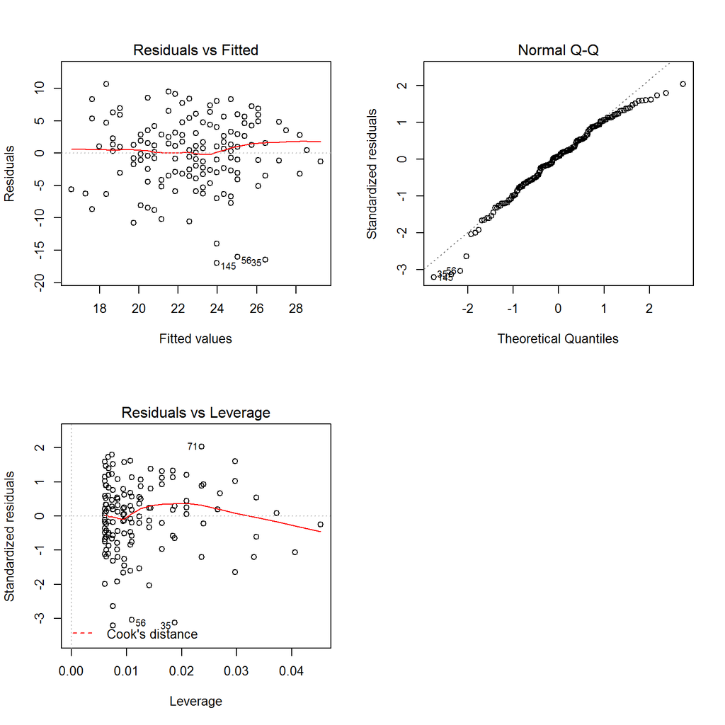

```r
par(mfrow = c(2,2))
plot(my_model, which=c(1,2,5))
```